# Chapter 4: Bayesian regression models

Shravan Vasishth (vasishth.github.io)

July 2025

# Textbook

Introduction to Bayesian Data Analysis for Cognitive Science

Nicenboim, Schad, Vasishth

- Online version: https://bruno.nicenboim.me/bayescogsci/
- Source code: https://github.com/bnicenboim/bayescogsci
- Physical book: [here](https://www.routledge.com/Introduction-to-Bayesian-Data-Analysis-for-Cognitive-Science/Nicenboim-Schad-Vasishth/p/book/9780367359331)

# Example: Multiple object tracking

Our research goal is to examine **how the attentional load affects pupil size**.

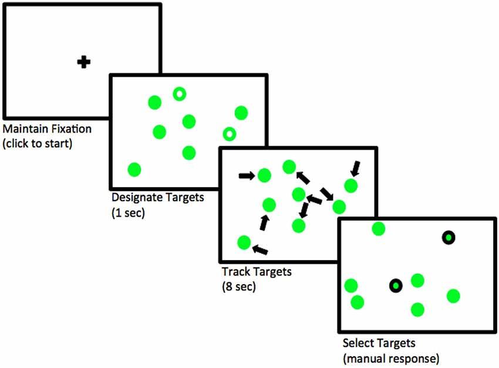

## A model for this design

A model for this experiment design:

$$\begin{equation}
p\_size_n \sim \mathit{Normal}(\alpha + c\_load_n \cdot \beta,\sigma)
\end{equation}$$

## Pilot data for working out priors

Some pilot data helps us work out priors:

```r
data("df_pupil_pilot")
df_pupil_pilot$p_size %>% summary()
```

```
##    Min. 1st Qu.  Median    Mean 3rd Qu.    Max.
##   851.5   856.0   862.0   860.8   866.5   868.0
```

This suggests we can use the following regularizing prior for $\alpha$:

$$\begin{equation}
\alpha \sim \mathit{Normal}(1000, 500)
\end{equation}$$

What we are expressing with this prior:

```r
qnorm(c(0.025, 0.975), mean = 1000, sd = 500)
```

```
## [1]   20.01801 1979.98199
```

For $\sigma$, we use an uninformative prior:

$$\begin{equation}
\sigma \sim \mathit{Normal}_+(0, 1000)
\end{equation}$$

```r
extraDistr::qtnorm(c(.025,0.975),
mean = 0, sd = 1000, a = 0)
```

```
## [1]   31.33798 2241.40273
```

$$\begin{equation}
\beta \sim \mathit{Normal}(0, 100)
\end{equation}$$

```r
qnorm(c(0.025, 0.975), mean = 0, sd = 100)
```

```
## [1] -195.9964  195.9964
```

## Fit the model

First, center the predictor:

```r
data("df_pupil")
(df_pupil <- df_pupil %>%
  mutate(c_load = load - mean(load)))
```

```
## # A tibble: 41 × 5
##     subj trial  load p_size c_load
##    <int> <int> <int>  <dbl>  <dbl>
##  1   701     1     2  1021. -0.439
##  2   701     2     1   951. -1.44
##  3   701     3     5  1064.  2.56
##  4   701     4     4   913.  1.56
##  5   701     5     0   603. -2.44
##  6   701     6     3   826.  0.561
##  7   701     7     0   464. -2.44
##  8   701     8     4   758.  1.56
##  9   701     9     2   733. -0.439
## 10   701    10     3   591.  0.561
## # ℹ 31 more rows
```

```r
fit_pupil <- brm(p_size ~ 1 + c_load,
  data = df_pupil,
  family = gaussian(),
  prior = c(
    prior(normal(1000, 500), class = Intercept),
    prior(normal(0, 1000), class = sigma),
    prior(normal(0, 100), class = b, coef = c_load)
  )
)
```

## Posterior distributions of the parameters

Next, we will plot the posterior distributions of the parameters, and the posterior predictive distributions for the different load levels.

```r
data("df_pupil")
(df_pupil <- df_pupil %>%
  mutate(c_load = load - mean(load)))

fit_pupil <- brm(p_size ~ 1 + c_load,
  data = df_pupil,
  family = gaussian(),
  prior = c(
    prior(normal(1000, 500), class = Intercept),
    prior(normal(0, 1000), class = sigma),
    prior(normal(0, 100), class = b, coef = c_load)
  )
)
```

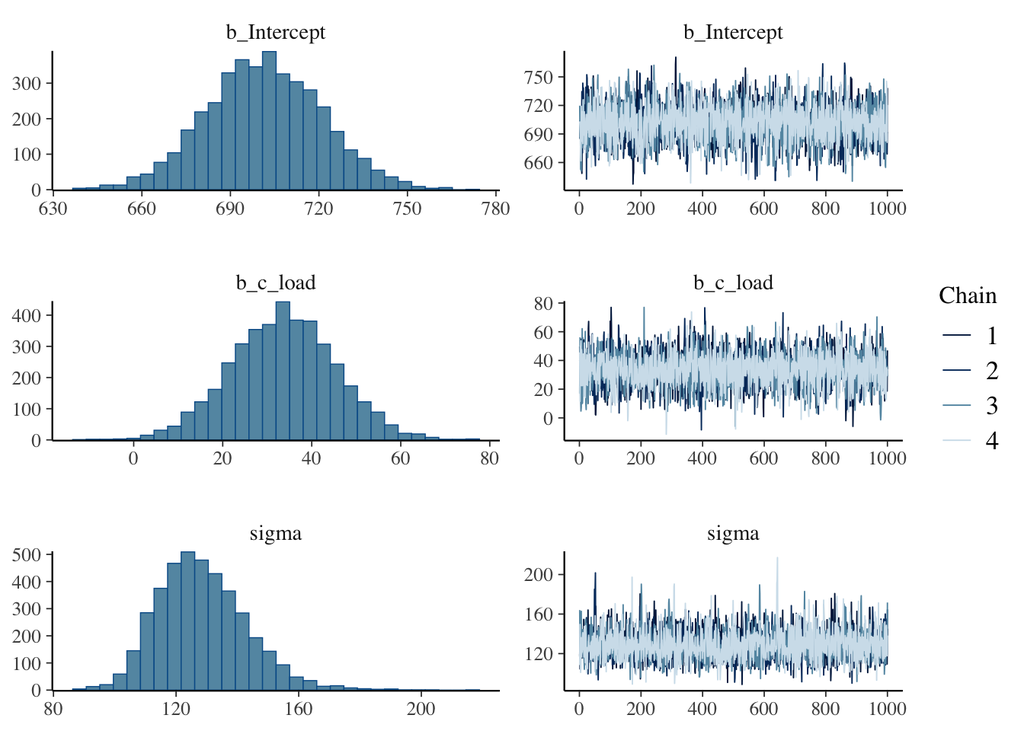

```r
plot(fit_pupil)
```

```r
## Note: short_summary is
## a function we wrote
short_summary(fit_pupil)
```

```
## ...
## Population-Level Effects:
##           Estimate Est.Error l-95% CI u-95% CI Rhat Bulk_ESS Tail_ESS
## Intercept   701.34     19.65   663.26   739.75 1.00     3024     2494
## c_load       33.62     11.82    10.44    56.70 1.00     3400     2829
##
## Family Specific Parameters:
##       Estimate Est.Error l-95% CI u-95% CI Rhat Bulk_ESS Tail_ESS
## sigma   128.51     14.67   104.15   160.19 1.00     3640     3131
##
## ...
```

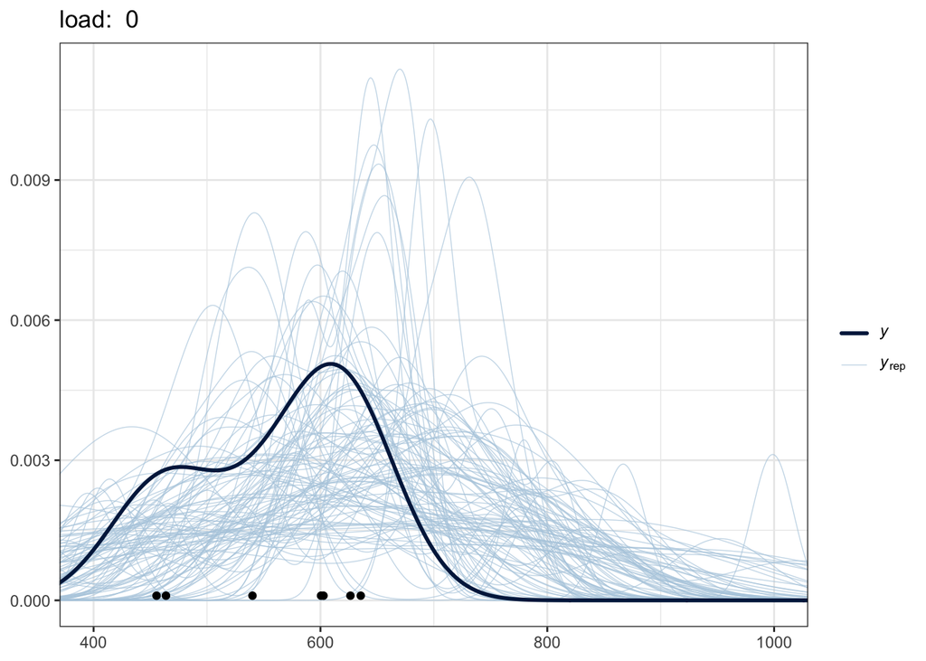

```r
l<-0
  df_sub_pupil <- filter(df_pupil, load == l)
  p <- pp_check(fit_pupil,
    type = "dens_overlay",
    ndraws = 100,
    newdata = df_sub_pupil
  ) +
    geom_point(data = df_sub_pupil,
    aes(x = p_size, y = 0.0001)) +
    ggtitle(paste("load: ", l)) +
    coord_cartesian(xlim = c(400, 1000)) +
    theme_bw()
  print(p)
```

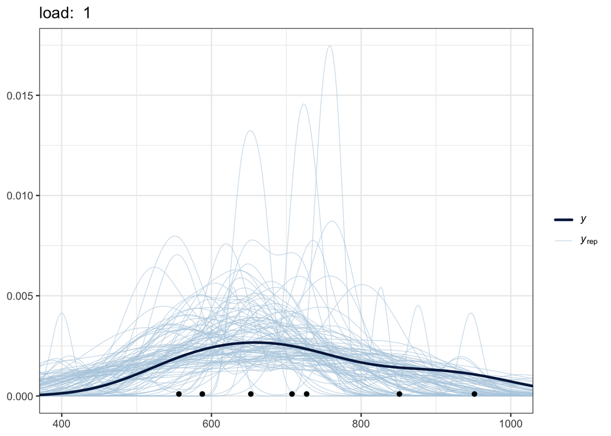

```r
l<-1
  df_sub_pupil <- filter(df_pupil, load == l)
  p <- pp_check(fit_pupil,
    type = "dens_overlay",
    ndraws = 100,
    newdata = df_sub_pupil
  ) +
    geom_point(data = df_sub_pupil,
    aes(x = p_size, y = 0.0001)) +
    ggtitle(paste("load: ", l)) +
    coord_cartesian(xlim = c(400, 1000)) +
    theme_bw()
  print(p)
```

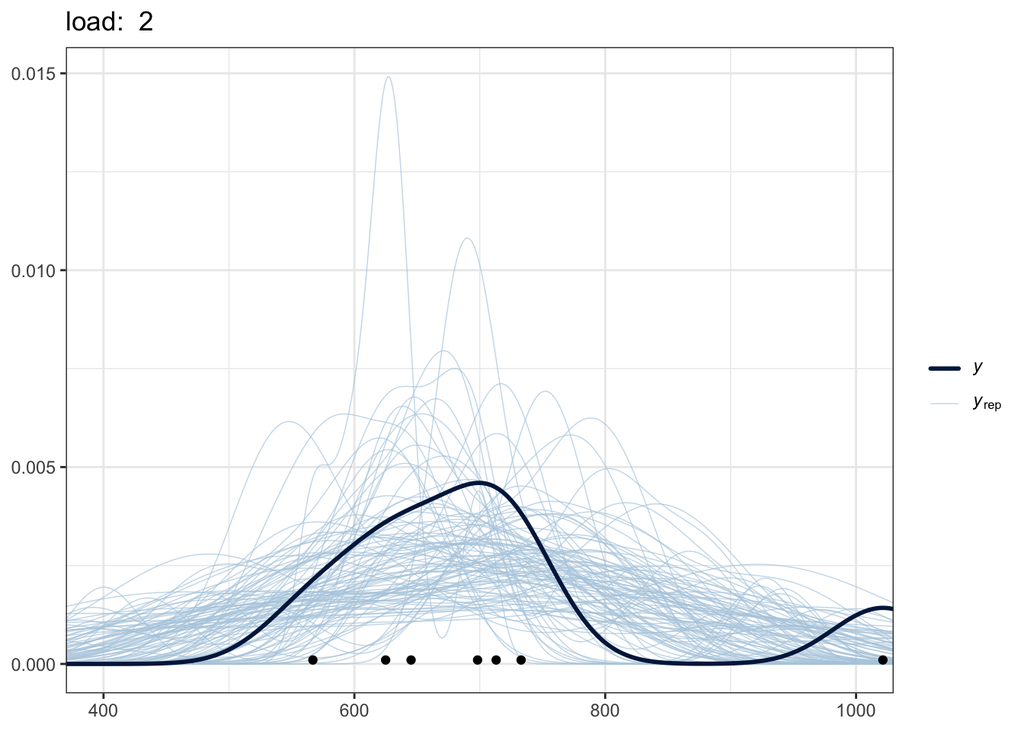

```r
l<-2
  df_sub_pupil <- filter(df_pupil, load == l)
  p <- pp_check(fit_pupil,
    type = "dens_overlay",
    ndraws = 100,
    newdata = df_sub_pupil
  ) +
    geom_point(data = df_sub_pupil,
    aes(x = p_size, y = 0.0001)) +
    ggtitle(paste("load: ", l)) +
    coord_cartesian(xlim = c(400, 1000)) + theme_bw()
  print(p)
```

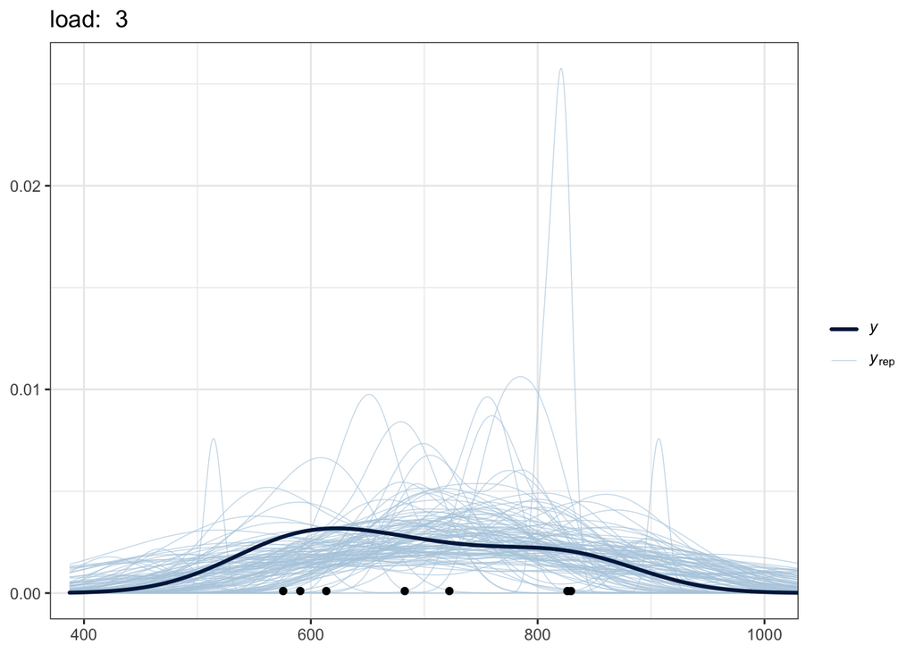

```r
l<-3
  df_sub_pupil <- filter(df_pupil, load == l)
  p <- pp_check(fit_pupil,
    type = "dens_overlay",
    ndraws = 100,
    newdata = df_sub_pupil
  ) +
    geom_point(data = df_sub_pupil,
    aes(x = p_size, y = 0.0001)) +
    ggtitle(paste("load: ", l)) +
    coord_cartesian(xlim = c(400, 1000)) +
    theme_bw()
  print(p)
```

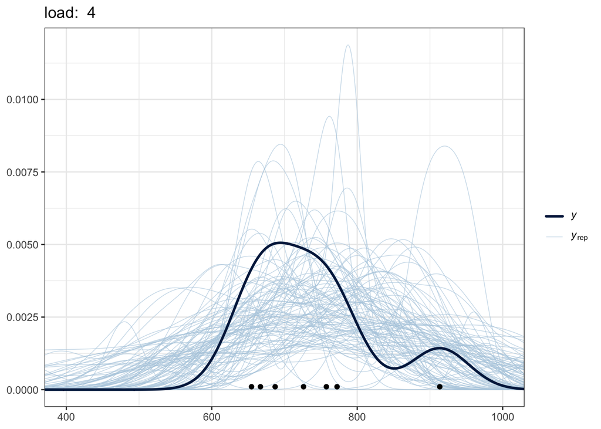

```r
l<-4
  df_sub_pupil <- filter(df_pupil,
  load == l)
  p <- pp_check(fit_pupil,
    type = "dens_overlay",
    ndraws = 100,
    newdata = df_sub_pupil
  ) +
    geom_point(data = df_sub_pupil,
    aes(x = p_size, y = 0.0001)) +
    ggtitle(paste("load: ", l)) +
    coord_cartesian(xlim = c(400, 1000)) +
    theme_bw()
  print(p)
```

## Using the log-normal likelihood

Next, we will look at another example: the effect of trial id on button-pressing times. This time, we will use the log-normal likelihood.

```r
df_spacebar <- df_spacebar %>%
  mutate(c_trial = trial - mean(trial))
```

If we assume that button-pressing times are log-normally distributed, we could proceed as follows:

$$\begin{equation}
t_n \sim \mathit{LogNormal}(\alpha + c\_trial_n \cdot \beta,\sigma)
\end{equation}$$

The priors have to be defined on the log scale:

$$\begin{equation}
\begin{aligned}
\alpha &\sim \mathit{Normal}(6, 1.5) \\
\sigma &\sim \mathit{Normal}_+(0, 1)\\
\end{aligned}
\end{equation}$$

A new parameter, $\beta$, needs a prior specification:

$$\begin{equation}
\beta \sim \mathit{Normal}(0, 1)
\end{equation}$$

This prior on $\beta$ is very uninformative.

## Prior predictive distributions

```r
df_spacebar_ref <- df_spacebar %>%
  mutate(rt = rep(1, n()))
fit_prior_press_trial <- brm(t ~ 1 + c_trial,
  data = df_spacebar_ref,
  family = lognormal(),
  prior = c(
    prior(normal(6, 1.5), class = Intercept),
    prior(normal(0, 1), class = sigma),
    prior(normal(0, 1), class = b,
    coef = c_trial)
  ),
  sample_prior = "only",
  control = list(adapt_delta = 0.9)
)
```

```
## Using all posterior draws for ppc type 'stat' by default.
```

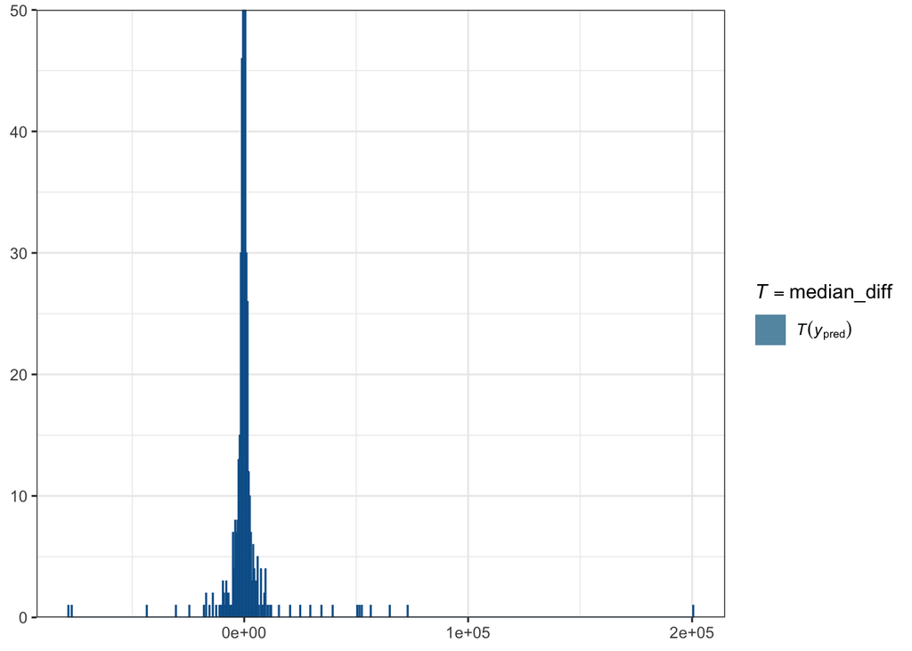

```r
median_diff <- function(x) {
  median(x - lag(x), na.rm = TRUE)
}
pp_check(fit_prior_press_trial,
         type = "stat",
         stat = "median_diff",
  # show only prior predictive
  # distributions
         prefix = "ppd",
  # each bin has a width of 500ms
         binwidth = 500) +
  # cut the top of the plot to improve its scale
  coord_cartesian(ylim = c(0, 50))+theme_bw()
```

What would the prior predictive distribution look like if we set the following more informative prior on $\beta$?

$$\begin{equation}
\beta \sim \mathit{Normal}(0, 0.01)
\end{equation}$$

```r
fit_prior_press_trial <- brm(t ~ 1 + c_trial,
  data = df_spacebar_ref,
  family = lognormal(),
  prior = c(
    prior(normal(6, 1.5), class = Intercept),
    prior(normal(0, 1), class = sigma),
    prior(normal(0, .01), class = b, coef = c_trial)
  ),
  sample_prior = "only",
  control = list(adapt_delta = .9)
)
```

```r
pp_check(fit_prior_press_trial,
         type = "stat",
         prefix = "ppd",
         binwidth = 50,
         stat = "median_diff") +
  coord_cartesian(ylim = c(0, 50))
```

```
## Using all posterior draws for ppc type 'stat' by default.
```

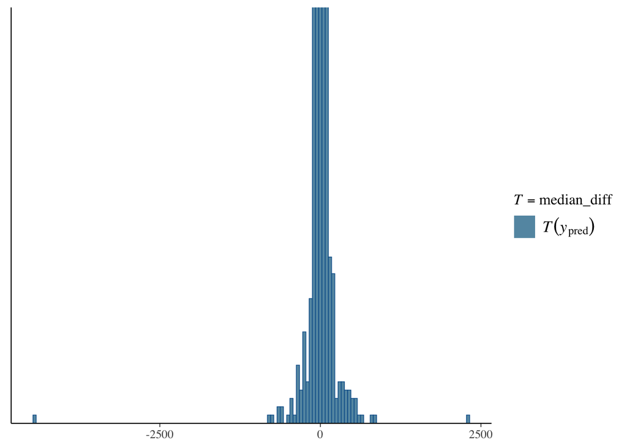

Now that we have decided on our priors, we fit the model.

```r
data("df_spacebar")
df_spacebar <- df_spacebar %>%
  mutate(c_trial = trial - mean(trial))
```

Fit the model:

```r
fit_press_trial <- brm(t ~ 1 + c_trial,
  data = df_spacebar,
  family = lognormal(),
  prior = c(
    prior(normal(6, 1.5), class = Intercept),
    prior(normal(0, 1), class = sigma),
    prior(normal(0, .01), class = b, coef = c_trial)
  )
)
```

Summarize posteriors (graphically or in a table, or both):

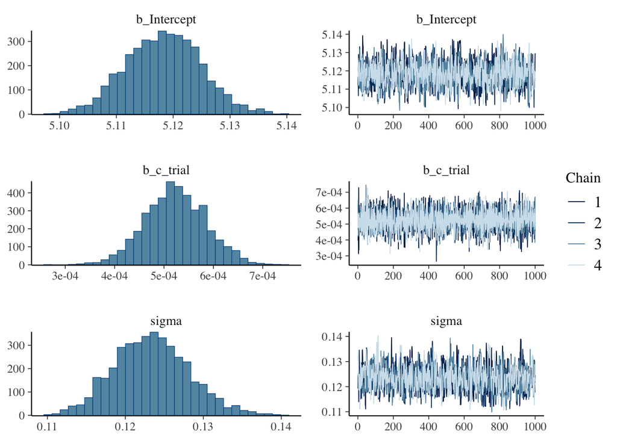

```r
plot(fit_press_trial)
```

Summarize results on the ms scale (the effect estimate from the middle of the expt to the preceding trial):

```r
alpha_samples <- as_draws_df(fit_press_trial)$b_Intercept
beta_samples <- as_draws_df(fit_press_trial)$b_c_trial

beta_ms <- exp(alpha_samples) -
           exp(alpha_samples - beta_samples)

beta_msmean <- round(mean(beta_ms), 5)
beta_mslow <- round(quantile(beta_ms, prob = 0.025), 5)
beta_mshigh <- round(quantile(beta_ms, prob = 0.975), 5)
c(beta_msmean , beta_mslow, beta_mshigh)
```

```
##            2.5%   97.5%
## 0.08736 0.06717 0.10779
```

The effect estimate at the first vs second trial:

```r
first_trial <- min(df_spacebar$c_trial)
second_trial <- min(df_spacebar$c_trial) + 1
effect_beginning_ms <-
  exp(alpha_samples + second_trial * beta_samples) -
  exp(alpha_samples + first_trial * beta_samples)
## ms effect from first to second trial:
c(mean = mean(effect_beginning_ms),
  quantile(effect_beginning_ms, c(0.025, 0.975)))
```

```
##       mean       2.5%      97.5%
## 0.07945231 0.06247444 0.09608793
```

Slowdown after 100 trials from the middle of the expt:

```r
effect_100 <-
  exp(alpha_samples + 100 * beta_samples) -
  exp(alpha_samples)
c(mean = mean(effect_100),
  quantile(effect_100, c(0.025, 0.975)))
```

```
##      mean      2.5%     97.5%
##  8.974166  6.855142 11.138285
```

The posterior predictive distribution (distribution of predicted median differences between the n and n-100th trial):

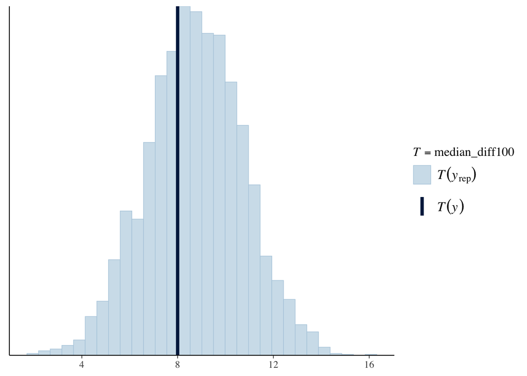

```r
median_diff100 <- function(x) median(x -
                   lag(x, 100), na.rm = TRUE)
pp_check(fit_press_trial,
         type = "stat",
         stat = "median_diff100")
```

# Logistic regression

```r
data("df_recall")
head(df_recall)
```

```
## # A tibble: 6 × 7
##   subj  set_size correct trial session block tested
##   <chr>    <int>   <int> <int>   <int> <int>  <int>
## 1 10           4       1     1       1     1      2
## 2 10           8       0     4       1     1      8
## 3 10           2       1     9       1     1      2
## 4 10           6       1    23       1     1      2
## 5 10           4       1     5       1     2      3
## 6 10           8       0     7       1     2      5
```

```r
df_recall <- df_recall %>%
  mutate(c_set_size = set_size - mean(set_size))
```

```r
# Set sizes in the data set:
df_recall$set_size %>%
  unique() %>% sort()
```

```
## [1] 2 4 6 8
```

```r
# Trials by set size
df_recall %>%
  group_by(set_size) %>%
  count()
```

```
## # A tibble: 4 × 2
## # Groups:   set_size [4]
##   set_size     n
##      <int> <int>
## 1        2    23
## 2        4    23
## 3        6    23
## 4        8    23
```

$$\begin{equation}
correct_n \sim \mathit{Bernoulli}(\theta_n)
\end{equation}$$

$$\begin{equation}
\eta_n = g(\theta_n) = \log\left(\frac{\theta_n}{1-\theta_n}\right)
\end{equation}$$

```r
x <- seq(0.001, 0.999, by = 0.001)
y <- log(x / (1 - x))
logistic_dat <- data.frame(theta = x, eta = y)

p1 <- qplot(logistic_dat$theta,
    logistic_dat$eta, geom = "line") +
  xlab(expression(theta)) +
  ylab(expression(eta)) +
  ggtitle("The logit link") +
  annotate("text",
    x = 0.3, y = 4,
    label = expression(paste(eta, "=",
                             g(theta))),
                             parse = TRUE,
    size = 8
  ) + theme_bw()
```

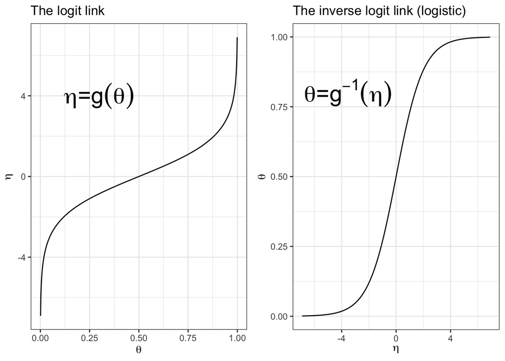

```r
p2 <- qplot(logistic_dat$eta, logistic_dat$theta,
            geom = "line") + xlab(expression(eta)) +
  ylab(expression(theta)) +
  ggtitle("The inverse logit link (logistic)") +
  annotate("text",
  x = -3.5, y = 0.80,
  label = expression(paste(theta, "=", g^-1,
                           (eta))),
                           parse = TRUE, size = 8
) + theme_bw()

gridExtra::grid.arrange(p1, p2, ncol = 2)
```

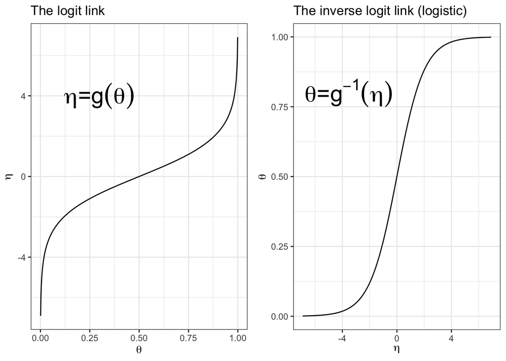

```r
x <- seq(0.001, 0.999, by = 0.001)
y <- log(x / (1 - x))
logistic_dat <- data.frame(theta = x, eta = y)

p1 <- qplot(logistic_dat$theta,
      logistic_dat$eta, geom = "line") +
      xlab(expression(theta)) +
      ylab(expression(eta)) +
      ggtitle("The logit link") +
      annotate("text",
      x = 0.3, y = 4,
      label = expression(paste(eta, "=",
      g(theta))), parse = TRUE, size = 8
  ) +
  theme_bw()


p2 <- qplot(logistic_dat$eta,
      logistic_dat$theta, geom = "line") +
      xlab(expression(eta)) +
      ylab(expression(theta)) +
      ggtitle("The inverse logit link (logistic)") +
      annotate("text",
  x = -3.5, y = 0.80,
  label = expression(paste(theta, "=", g^-1, (eta))),
  parse = TRUE, size = 8
) + theme_bw()

gridExtra::grid.arrange(p1, p2, ncol = 2)
```

## Deciding on priors

```r
data("df_recall")
head(df_recall)
```

```
## # A tibble: 6 × 7
##   subj  set_size correct trial session block tested
##   <chr>    <int>   <int> <int>   <int> <int>  <int>
## 1 10           4       1     1       1     1      2
## 2 10           8       0     4       1     1      8
## 3 10           2       1     9       1     1      2
## 4 10           6       1    23       1     1      2
## 5 10           4       1     5       1     2      3
## 6 10           8       0     7       1     2      5
```

```r
df_recall <- df_recall %>%
  mutate(c_set_size = set_size - mean(set_size))
```

The linear model is now fit not to the 0,1 responses as the dependent variable, but to $\eta_n$, i.e., log-odds, as the dependent variable:

$$\begin{equation}
\eta_n = \log\left(\frac{\theta_n}{1-\theta_n}\right) = \alpha + \beta
\cdot c\_set\_size_n
\end{equation}$$

This gives the above-mentioned logistic regression function:

$$\begin{equation}
\theta_n = g^{-1}(\eta_n) = \frac{\exp(\eta_n)}{1+\exp(\eta_n)} =
\frac{1}{1+exp(-\eta_n)}
\end{equation}$$

In summary, the generalized linear model with the logit link fits the following Bernoulli likelihood:

$$\begin{equation}
correct_n \sim \mathit{Bernoulli}(\theta_n)
\end{equation}$$

$$\begin{equation}
\alpha \sim \mathit{Normal}(0, 4)
\end{equation}$$

Let’s plot this prior in log-odds and in probability scale by drawing random samples.

Prior for $\alpha \sim \mathit{Normal}(0, 4)$ in log-odds and in probability space.

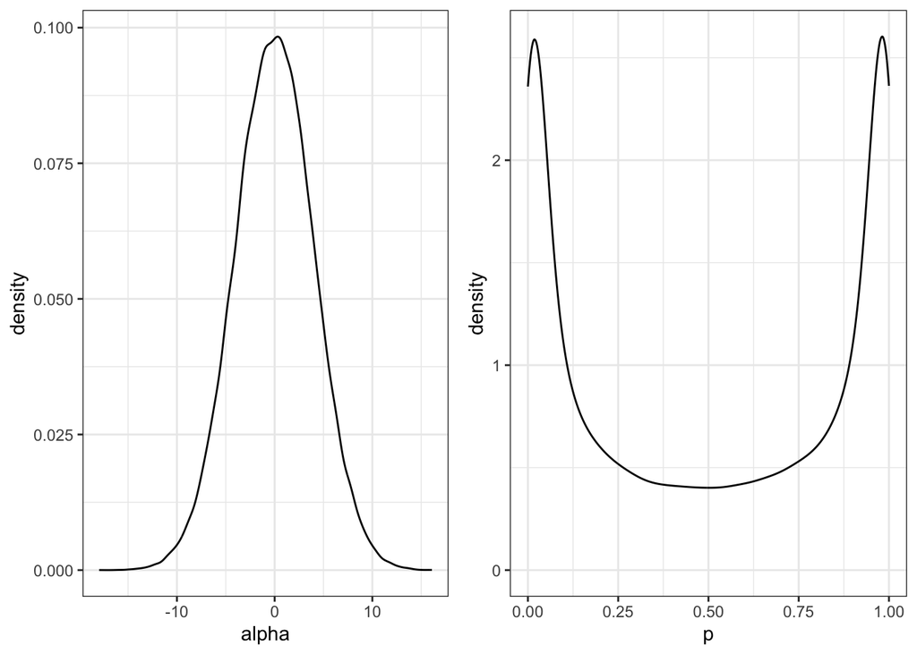

```r
samples_logodds <- tibble(alpha = rnorm(100000,
                   0, 4))
samples_prob <- tibble(p = plogis(rnorm(100000,
                  0, 4)))
pa<-ggplot(samples_logodds, aes(alpha)) +
  geom_density()+theme_bw()
pb<-ggplot(samples_prob, aes(p)) +
  geom_density()+theme_bw()
gridExtra::grid.arrange(pa, pb, ncol = 2)
```

$$\begin{equation}
\alpha \sim \mathit{Normal}(0, 1.5)
\end{equation}$$

Prior for $\alpha \sim \mathit{Normal}(0, 1.5)$ in log-odds and in probability space.

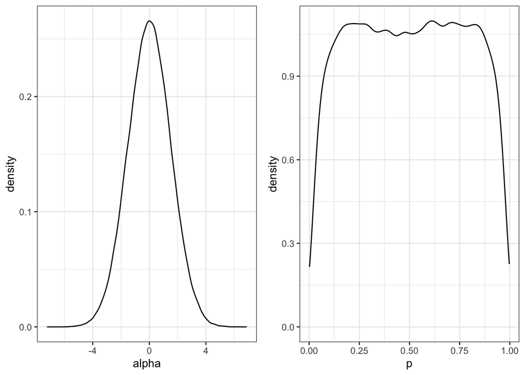

```r
samples_logodds <- tibble(alpha = rnorm(100000,
                   0, 1.5))
samples_prob <- tibble(p = plogis(rnorm(100000,
                  0, 1.5)))
paa<-ggplot(samples_logodds, aes(alpha)) +
  geom_density()+theme_bw()
pbb<-ggplot(samples_prob, aes(p)) +
  geom_density()+theme_bw()
gridExtra::grid.arrange(paa, pbb, ncol = 2)
```

We can examine the consequences of each of the following prior specifications:

```r
logistic_model_pred <- function(alpha_samples,
                       beta_samples,
                       set_size,N_obs) {
  map2_dfr(alpha_samples, beta_samples,
    function(alpha, beta) {
      tibble(
        set_size = set_size,
        # center size:
        c_set_size = set_size - mean(set_size),
        # change the likelihood:
        theta = plogis(alpha + c_set_size * beta),
        correct_pred = extraDistr::rbern(n = N_obs,
        prob = theta)
      )
    },
    .id = "iter"
  ) %>%
    # .id is always a string and has to
    # be converted to a number
    mutate(iter = as.numeric(iter))
}
```

```r
N_obs <- 800
set_size <- rep(c(2, 4, 6, 8), 200)
```

```r
alpha_samples <- rnorm(1000, 0, 1.5)
sds_beta <- c(1, 0.5, 0.1, 0.01, 0.001)
prior_pred <- map_dfr(sds_beta, function(sd) {
  beta_samples <- rnorm(1000, 0, sd)
  logistic_model_pred(
    alpha_samples = alpha_samples,
    beta_samples = beta_samples,
    set_size = set_size,
    N_obs = N_obs
  ) %>%
    mutate(prior_beta_sd = sd)
})
```

```r
mean_accuracy <-
  prior_pred %>%
  group_by(prior_beta_sd, iter, set_size) %>%
  summarize(accuracy = mean(correct_pred)) %>%
  mutate(prior = paste0("Normal(0, ",
  prior_beta_sd, ")"))
```

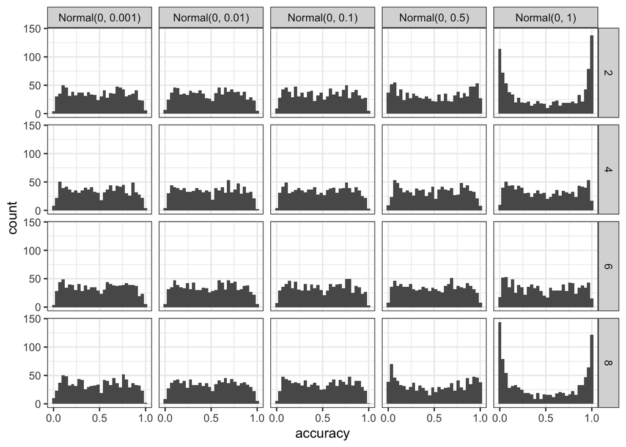

```r
mean_accuracy %>%
  ggplot(aes(accuracy)) +
  geom_histogram() +
  facet_grid(set_size ~ prior) +
  scale_x_continuous(breaks = c(0, 0.5, 1))+
  theme_bw()
```

It’s usually more useful to look at the predicted differences in accuracy between set sizes.

```r
diff_accuracy <- mean_accuracy %>%
  arrange(set_size) %>%
  group_by(iter, prior_beta_sd) %>%
  mutate(diff_accuracy = accuracy - lag(accuracy)) %>%
  mutate(diffsize = paste(set_size, "-",
  lag(set_size))) %>%
  filter(set_size > 2)
```

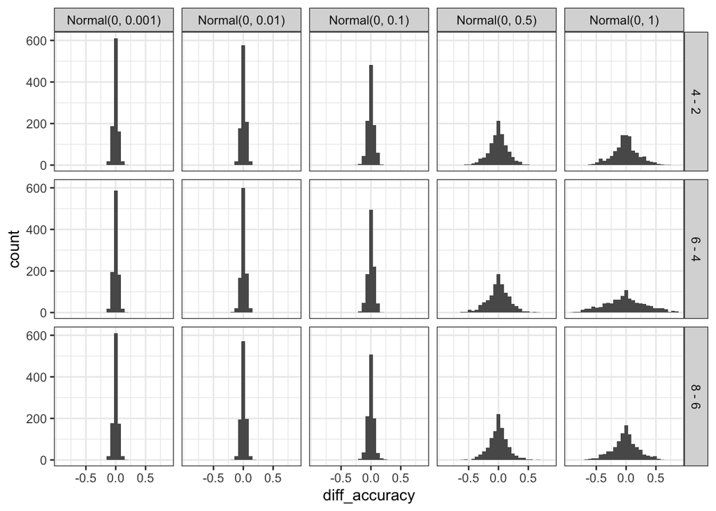

```r
diff_accuracy %>%
  ggplot(aes(diff_accuracy)) +
  geom_histogram() +
  facet_grid(diffsize ~ prior) +
  scale_x_continuous(breaks = c(-0.5, 0, 0.5)) +
  theme_bw()
```

These priors seem reasonable:

$$\begin{equation}
\begin{aligned}
\alpha &\sim \mathit{Normal}(0, 1.5) \\
\beta &\sim \mathit{Normal}(0, 0.1)
\end{aligned}
\end{equation}$$

## Fit the model

Next: fit the model and examine the posterior distributions of the parameters.

```r
data("df_recall")
head(df_recall)
```

```
## # A tibble: 6 × 7
##   subj  set_size correct trial session block tested
##   <chr>    <int>   <int> <int>   <int> <int>  <int>
## 1 10           4       1     1       1     1      2
## 2 10           8       0     4       1     1      8
## 3 10           2       1     9       1     1      2
## 4 10           6       1    23       1     1      2
## 5 10           4       1     5       1     2      3
## 6 10           8       0     7       1     2      5
```

```r
df_recall <- df_recall %>%
  mutate(c_set_size = set_size - mean(set_size))
```

```r
fit_recall <- brm(correct ~ 1 + c_set_size,
  data = df_recall,
  family = bernoulli(link = logit),
  prior = c(
    prior(normal(0, 1.5), class = Intercept),
    prior(normal(0, .1), class = b,
    coef = c_set_size)
  )
)
```

```r
posterior_summary(fit_recall,
                  variable = c("b_Intercept",
                  "b_c_set_size"))
```

```
##                Estimate  Est.Error       Q2.5       Q97.5
## b_Intercept   1.9186872 0.31170072  1.3393863  2.56051639
## b_c_set_size -0.1857682 0.08249934 -0.3481115 -0.02183755
```

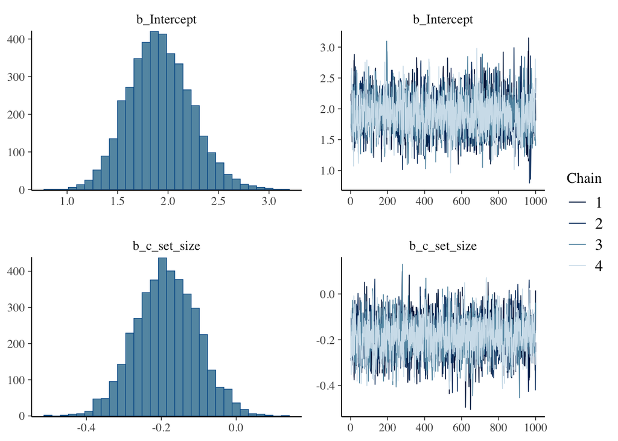

```r
plot(fit_recall)
```

```r
alpha_samples <- as_draws_df(fit_recall)$b_Intercept
beta_samples <- as_draws_df(fit_recall)$b_c_set_size
beta_mean <- round(mean(beta_samples), 5)
beta_low <- round(quantile(beta_samples,
            prob = 0.025), 5)
beta_high <- round(quantile(beta_samples,
            prob = 0.975), 5)

alpha_samples <- as_draws_df(fit_recall)$b_Intercept
av_accuracy <- plogis(alpha_samples)
c(mean = mean(av_accuracy), quantile(av_accuracy,
                            c(0.025, 0.975)))
```

```
##      mean      2.5%     97.5%
## 0.8680289 0.7923890 0.9282768
```

## Does set size affect free recall?

Find out the decrease in accuracy in proportions or probability scale:

```r
beta_samples <- as_draws_df(fit_recall)$b_c_set_size
effect_middle <- plogis(alpha_samples) -
  plogis(alpha_samples - beta_samples)
c(mean = mean(effect_middle),
  quantile(effect_middle, c(0.025, 0.975)))
```

```
##         mean         2.5%        97.5%
## -0.019149397 -0.037311590 -0.002381394
```

```r
four <- 4 - mean(df_recall$set_size)
two <- 2 - mean(df_recall$set_size)
effect_4m2 <-
  plogis(alpha_samples + four * beta_samples) -
  plogis(alpha_samples + two * beta_samples)
c(mean = mean(effect_4m2),
  quantile(effect_4m2, c(0.025, 0.975)))
```

```
##         mean         2.5%        97.5%
## -0.029846420 -0.054348471 -0.004646373
```

## Conclusion (careful about the wording!)

The posterior distributions of the parameters (transformed to probability scale) are consistent with the claim that increasing set size reduces accuracy.

**Notice that I did not write any of the following sentences**:

- “There is a significant effect of set size on accuracy”. This sentence is basically nonsensical since we didn’t do a frequentist significance test.
- “We found that set size reduces accuracy”: That is a discovery claim. Such a claim of the existence of an effect requires us to quantify the evidence for a model assuming that set size affects accuracy, relative to a baseline model. Later, we will use Bayes factors (or, even later, k-fold cross validation).

The wording I used simply states that the observed **pattern** is consistent with set size reducing accuracy. I am careful not to make a discovery claim. In particular, I am not claiming that I found a general truth about the nature of things.